# FastTrack advanced user guide

In this advanced user guide, we will assume that you already finished the user guide and that you already know the following :

- The format of the rawCounts xlsx input file
- The format of the sampleData xlsx input file
- How to use RStudio to run R code

## Step 1 : Import libraries

```r
library(hgu133plus2.db)
library(pheatmap)
library(ggplot2)
library(DESeq2)
library(readxl)
library(writexl)
library(tibble)
library(scales)
library(viridis)
library(tidyr)
```

### Step 2 : Input information needed by FastTrack

- *rawCountsFile* that contains the location of the xlsx rawCounts file
- *sampleDataFile* that contains the location of the xlsx sampleData file
- *ID_TYPE* that contains the type of ID for the RNA strands in the rawCountsFile it must be one of the value displayed below
- *Compare* that contains the name of the property that will be compared the analysis
- *order* a vector that contains the order of comparison of the properties values
- *threshold* that contains the minimal number of read count to keep the considered gene/transcript
- *saveFolder* that contains the location of the folder where the results will be saved

```r
rawCountsFile <- "RawCounts.xlsx"
sampleDataFile <- "SampleData.xlsx"
ID_TYPE <- "PROBEID"
Compare <- "Disease"
order <- c("normal", "invasive ductal carcinoma")
threshold <- 5
saveFolder <- "Results"
```

### Step 3 : Creation of the folder to save results

Creation of the folder *saveFolder* using the function *dir.create()*

```r
dir.create(saveFolder)
```

### Step 4 : Creation of the mapping between RNA IDs

The goal of this step is to create a mapping between the RNA IDs in the *rawCountsFile* file and the RNA ID types *GENEAME* and *SYMBOL*.

To do so, we are going to use the Bioconductor Package *hgu133plus2.db* for annotations. For more details about *hgu133plus2.db*, you can check the Bioconductor Package [homepage](https://bioconductor.org/packages/release/data/annotation/html/hgu133plus2.db.html) and the [documentation](https://bioconductor.org/packages/release/data/annotation/manuals/hgu133plus2.db/man/hgu133plus2.db.pdf).

First, we print out the supported RNA ID types. To do so, we use the function *columns* from *hgu133plus2.db* ans print the output.

```r
print(columns(hgu133plus2.db))
```

```
 [1] "ACCNUM"       "ALIAS"        "ENSEMBL"      "ENSEMBLPROT"  "ENSEMBLTRANS" "ENTREZID"     "ENZYME"
 [8] "EVIDENCE"     "EVIDENCEALL"  "GENENAME"     "GENETYPE"     "GO"           "GOALL"        "IPI"
[15] "MAP"          "OMIM"         "ONTOLOGY"     "ONTOLOGYALL"  "PATH"         "PFAM"         "PMID"
[22] "PROBEID"      "PROSITE"      "REFSEQ"       "SYMBOL"       "UCSCKG"       "UNIPROT"
```

As stated in the user guide, the RNA ID type in the *rawCountsFile* must be in the list displayed above.

First, we store all the possible IDs of type *ID_TYPE* in the variable *k* by using the function *keys* from the *hgu133plus2.db* library. We also print the first 10 elements to make sure that the ID type is correct.

```r
k <- keys(hgu133plus2.db,keytype=ID_TYPE)
print(k[1:10])
```

```
 [1] "1007_s_at" "1053_at"   "117_at"    "121_at"    "1255_g_at" "1294_at"   "1316_at"   "1320_at"   "1405_i_at"
[10] "1431_at"
```

We then create the mapping between the *ID_TYPE* and *GENENAME* using the function *AnnotationDbi::select* from the *hgu133plus2.db* library. We print the first five rows of the mapping with the function *head* to make sure that the mapping is correct.

```r
mapping<-AnnotationDbi::select(hgu133plus2.db, keys=k, columns=c("GENENAME"), keytype=ID_TYPE)
print(head(mapping))
```

|  | PROBEID | GENENAME |
| --- | --- | --- |
| 1 | 1007_s_at | discoidin domain receptor tyrosine kinase 1 |
| 2 | 1053_at | replication factor C subunit 2 |
| 3 | 117_at | heat shock protein family A (Hsp70) member 6 |
| 4 | 121_at | paired box 8 |
| 5 | 1255_g_at | guanylate cyclase activator 1A |
| 6 | 1294_at | ubiquitin like modifier activating enzyme 7 |

We delete some *ID_TYPE* that may have been duplicated, change the rownames of *mapping* from integers to their associated *ID_TYPE*, we remove the *ID_TYPE* column (it is no longer useful since the IDs are the names of the rows) and store the new mapping in the variable *mapping_G*.

```r
mapping<-mapping[!duplicated(mapping[[ID_TYPE]]), ]
rownames(mapping) <- mapping[[ID_TYPE]]
mapping_G <- subset(mapping, select = -get(ID_TYPE))
head(mapping_G)
```

|  | GENENAME |
| --- | --- |
| 1007_s_at | discoidin domain receptor tyrosine kinase 1 |
| 1053_at | replication factor C subunit 2 |
| 117_at | heat shock protein family A (Hsp70) member 6 |
| 121_at | paired box 8 |
| 1255_g_at | guanylate cyclase activator 1A |
| 1294_at | ubiquitin like modifier activating enzyme 7 |

We repeat the same process for the *SYMBOL* ID TYPE.

```r
mapping<-AnnotationDbi::select(hgu133plus2.db, keys=k, columns=c("SYMBOL"), keytype=ID_TYPE)
mapping<-mapping[!duplicated(mapping[[ID_TYPE]]), ]
rownames(mapping) <- mapping[[ID_TYPE]]
mapping_S <- subset(mapping, select = -get(ID_TYPE))
```

We store both mappings *mapping_S* and *mapping_G* in the list *mapping*.

```r
mapping <- list(mapping_G = mapping_G, mapping_S = mapping_S)
```

### Step 5 : Reading and controlling the xlsx files

We read the xlsx files using the function *read_excel* from the *readxl* library and store the data in a *data.frame*.

```r
rawCounts <- data.frame(read_excel(rawCountsFile))
sampleData <- data.frame(read_excel(sampleDataFile))
```

A *data.frame* is a common structure used in *R* to store data. It represents data as a table composed of rows and columns. For example, the *data.frame* named *sampleData* obtained from reading the *sampleDataFile* has two columns named *SampleID* and *Disease* :

```r
print(sampleData)
```

| SampleID | Disease |
| --- | --- |
| Sample_1 | invasive ductal carcinoma |
| Sample_2 | invasive ductal carcinoma |
| Sample_3 | invasive ductal carcinoma |
| Sample_4 | normal |
| Sample_5 | normal |
| Sample_6 | normal |

To perform differential analysis, we use the *DESeq2* library which needs to have the rawCounts as a matrix and not a *data.frame*. In the following, we convert rawCounts into a matrix and name its rows using the values in the *RNA_ID* column og the *rawCountsFile*.

```r
RNA_ID <- rawCounts$RNA_ID
rawCounts <- as.matrix(subset(rawCounts, select = -RNA_ID))
rownames(rawCounts) <- RNA_ID
```

For *DESeq2* to work, we also need to remove all spaces from the names in the variables *sampleData* and *order* :

```r
sampleData <- as.data.frame(apply(sampleData, 2, function(x) gsub("\\s+", "_", x)))
order <- gsub("\\s+", "_", order)
```

We are also going to remove the *SampleID* column from *sampleData* and use it as name for the rows of *sampleData*. *DESeq2* also needs to have the column of *sampleData* that corresponds to the property we want to compare as a factor (an immutable structure for storing data).

```r
SampleID = sampleData$SampleID
rownames(sampleData) <- SampleID
sampleData <- subset(sampleData, select = -SampleID)
sampleData[[Compare]] <- factor(sampleData[[Compare]])
```

We make sure that the columns of *rawCounts* have the same values as the rows of *sampleData* that both corresponds to the sample IDs of the experiment. If *TRUE* is printed it means the columns of *rawCounts* have the same values as the rows of *sampleData*, otherwise there is a problem with the values in the xlsx files.

```r
rawCounts <- rawCounts[,unique(rownames(sampleData))]
print(all(colnames(rawCounts) == rownames(sampleData)))
```

```
[1] TRUE
```

```r
sampleData[[Compare]] <- factor(sampleData[[Compare]], levels=order)
```

We store the variables *rawCounts* and *sampleData* in the list *rawData*. And we also build a varaible containing the log transformed values of the rawCounts. The *+ 1* is here to avoid infinite values, since in R *log(0)=-Inf*, if there are Counts equal to 0 logRawCounts will contain *-Inf* values. We add 1 to the Counts in order to avoid this case.

```r
rawData<-list(rawCounts = rawCounts, sampleData = sampleData)
logRawCounts <- log2(rawData$rawCounts + 1)
```

### Step 6 : PCA

We perform Principal Component Analysis using the function *prcomp* from [RDocumentation](https://www.rdocumentation.org/packages/stats/versions/3.6.2/topics/prcomp).

```r
PCA_raw <- prcomp(t(logRawCounts))
```

Reminder of PCA :

PCA can be seen as a method to summarize data. In our case, each of the 6 samples will be associated with 6 values called their principal component. These values can be displayed from the PCA_raw variable we just computed :

```r
print(PCA_raw$x)
```

```
                PC1         PC2        PC3         PC4        PC5           PC6
Sample_1  -84.99658 -132.707885   34.48035   -2.170814 -11.681841 -4.351800e-13
Sample_2  167.93001   12.489715   19.96361    5.799126 -70.158617  1.006296e-12
Sample_3  124.23109   -6.167741   21.56953   11.157987  84.250034  1.309873e-12
Sample_4  -35.43987   28.462171  -47.60665 -113.214304   2.643767 -3.043206e-14
Sample_5  -45.83663    9.059577 -104.49085   72.879162  -2.749654 -3.359200e-13
Sample_6 -125.88802   88.864163   76.08401   25.548843  -2.303689 -1.427559e-12
```

**IMPORTANT NOTE** : In our case, we do not care about the individual PC values of each sample. What matters is the relative values between each samples since we use PCA to have a global understanding of the difference between the samples (if there are any).

Note that the principal componenets (PC) are ordered from 1 to 6 and this order is important to summarize the data. The intuition of PCA is that if given a sample and it’s first principal component PC1, we will be able to approximate the rawCounts of that sample. If we take the first two principal component, PC1 and PC2, the approximation will be more precise. The more PC we take into account, the better the approximation. However the more PC we add, the less information we obtain from each new PC. That can be seen by displaying the variance of each PC :

```r
print(PCA_raw$sdev^2)
```

```
[1] 1.401261e+04 5.318885e+03 4.205238e+03 3.788887e+03 2.435324e+03 1.395502e-25
```

```r
percentVar <- round(100*PCA_raw$sdev^2/sum(PCA_raw$sdev^2),1)
```

The first PC has a variance $\approx 10000$ whereas the final PC has a variance $\approx 10^{-25}$. Which means that the values of PC1 are very spread which allow us to distinguish the samples from one another much more than the values of PC6.

Next, we are going to plot the samples in a 2D plan where the dimension corresponds to the values of the first two PC. This will allow us to quickly see if there is a notable difference between the samples counts values.

We start be storing the first two PC values and the *Compare* property values of each sample in a *data.frame*. We also give the colmuns of the *data.frame* appropriate names.

```r
dataGG <- data.frame("PC1" = PCA_raw$x[,1], "PC2" = PCA_raw$x[,2], "tmp" = sampleData[,Compare])
colnames(dataGG) = c("PC1","PC2",Compare)
```

We use the function *ggplot* from the library *ggplot2* to plot the PCA. The option *geom_point* is used to create scatterplots. We give different shapes to the samples having different *Compare* property values.

We use *ggtitle*, *xlab* and *ylab* to put a title on the plot and on the two axis. The value $percentVar[1]$ corresponds the the normalised variance of PC1 and can be interprteted as the amount of information contained in the first PC. In this example, we can say that the first principal component contains $47.1\%$ of the information needed to perfectly approximate the rawCounts. If we use the first two PC, we go up to $65.0\%$. We can also see that using only the fist two PC, we can distinguish “normal” from “invasive ductal carcinomia” samples.

With the option *theme*, we choose the size of the title.

*scale_shape_manual* allows us to choose the shape of the samples representations in the plot.

The function *print* displays the plot and *ggsave(file.path(saveFolder, “PCA.pdf”))* saves the plot as a pdf in the directory *saveFolder* with the name *PCA.pdf*.

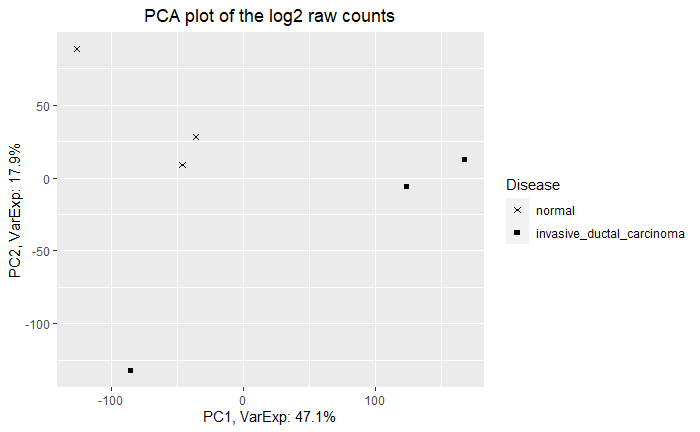

```r
p <- ggplot(dataGG, aes(PC1, PC2)) +
  geom_point(aes_string(shape = Compare)) +
  ggtitle("PCA plot of the log2 raw counts") +
  xlab(paste0("PC1, VarExp: ", percentVar[1], "%")) +
  ylab(paste0("PC2, VarExp: ", percentVar[2], "%")) +
  theme(plot.title = element_text(hjust = 0.5))+
  scale_shape_manual(values = c(4,15))

print(p)

ggsave(file.path(saveFolder, "PCA.pdf"))
```

### Step 7 : Boxplot of the log2 of the raw Counts

In order to print the boxplot of the data, we have to stack the *data.frame* of the *logRawCounts*. That means transforming the *data.frame* to have only two columns : *SampleID* (named ind) and *logRawCount* (named values). After that, we just need to use *aes* to tell which columns to use for the x axis and the y axis. We can use the *geom_boxplot* option to set the size of outliers.

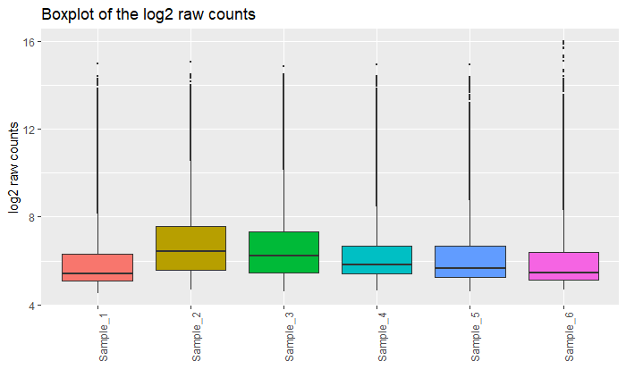

```r
p <- ggplot(stack(data.frame(logRawCounts)), aes(x = ind, y = values, fill=ind)) +
  xlab("") +
  ylab("log2 raw counts")  +
  theme(legend.position = "none") +
  geom_boxplot(outlier.size = 0.1) +
  labs(title="Boxplot of the log2 raw counts") +
  theme(axis.text.x = element_text(angle = 90))
print(p)
ggsave(file.path(saveFolder, "boxplot_log2_raw_counts.pdf"))
```

This plot shows us that all the samples contains a lot of outliers (extreme values), even after using the log2 to smooth the values.

### Step 8 : Plot the histogram of log2 counts and set the thresold

Printing the histogram of log2 counts allow us to visualize the distribution of these values and to set a threshold to filter our some RNA strands that have very low counts. This filtering speeds up the analysis and removes noise from the data without having a negative impact on the analysis since we remove only the RNA strands that have low expression. You can change the value of the variable *threshold* and launch the code below again to see the red line changing position. Once you are satisfied with the threshold, you can start the differential analysis.

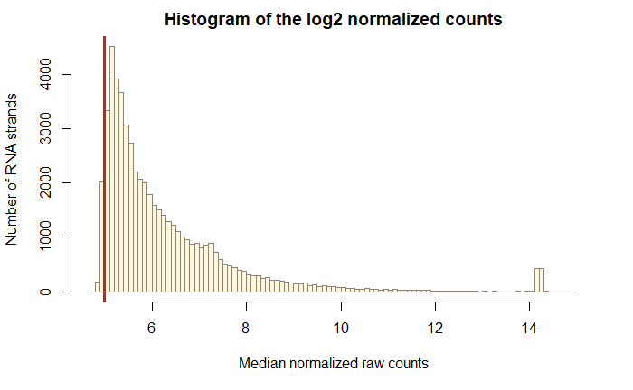

```r
medians <- rowMedians(log2(rawData$rawCounts))

hist_res <- hist(medians, 100, col = "cornsilk", freq = TRUE,
                 main = "Histogram of the log2 normalized counts",
                 border = "antiquewhite4",
                 xlab = "Median normalized raw counts",
                 ylab = "Number of RNA strands")
abline(v = threshold, col = "coral4", lwd = 3)
```

```r
dev.print(pdf, file.path(saveFolder, 'hist_median_intensities.pdf'))
```

### Step 9 : Perform differential analysis

As stated previously, we perform differential analysis using the library *DESEQ2*.

First, we transform the data in a structure that is needed by *DESEQ2* using the function *DESeqDataSetFromMatrix*:

```r
deseq2Data <- DESeqDataSetFromMatrix(countData=rawData$rawCounts, colData=rawData$sampleData,
                                       design=as.formula(paste("~", Compare, sep="")))
```

Then, we apply the threshold that we defined previously by removing rows that have a median log2 count smaller than the threshold :

```r
deseq2Data <- deseq2Data[rowMedians(log2(counts(deseq2Data))) > threshold, ]
```

Finally, we perform differential analysis (may take a few minutes) :

```r
deseq2Data <- DESeq(deseq2Data)
```

```
-- note: fitType='parametric', but the dispersion trend was not well captured by the
   function: y = a/x + b, and a local regression fit was automatically substituted.
   specify fitType='local' or 'mean' to avoid this message next time.
```

### Step 9 : Control the normalized data

Now that we have performed differential analysis, we are going to control the normalized counts values obtained by *DESEQ2* by using a boxplot, a PCA plot and a heatmap.

First, we print a boxplot of deviation of log2 normalized counts for each sample. To get the normalized counts, we us the function *counts(deseq2Data, normalized=TRUE)*. We obtain the deviation by comparing the values to their median using the *sweep* function. The function *tidyr::gather* has the same goal as the *stack* used in the previous boxplot. The rest of the code is similar to what was done previously.

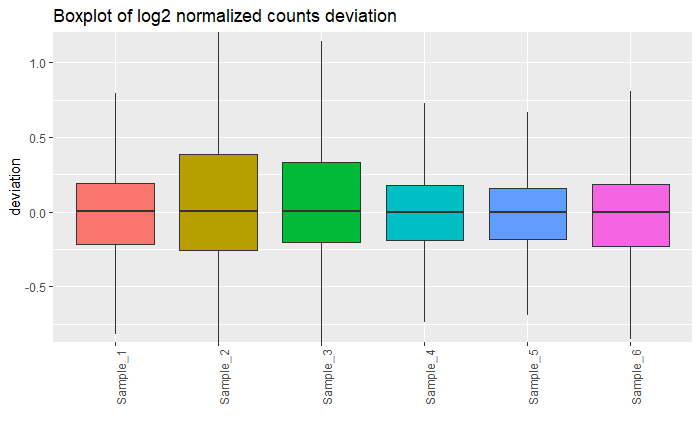

```r
normalized_counts<-log2(counts(deseq2Data, normalized=TRUE)+1)
row_medians_assayData <- Biobase::rowMedians(as.matrix(normalized_counts))
RLE_data <- sweep(normalized_counts, 1, row_medians_assayData)
RLE_data <- as.data.frame(RLE_data)
RLE_data_gathered <- tidyr::gather(RLE_data, sample_array, log_expr_dev)
p <- ggplot(RLE_data_gathered, aes(x = sample_array, y = log_expr_dev, fill=sample_array)) +
  xlab("") +ylab("deviation")  + theme(legend.position = "none") +
  geom_boxplot(outlier.shape = NA) +
  coord_cartesian(ylim = quantile(RLE_data_gathered$log_expr_dev, c(0.05, 0.95))) +
  labs(title="Boxplot of log2 normalized counts deviation")+
  theme(axis.text.x = element_text(angle = 90))
print(p)
ggsave(file.path(saveFolder, "boxplot_normalized_deviation.pdf"))
```

Then, we plot the first two Principal Components of the normalized counts. The code is similar as before.

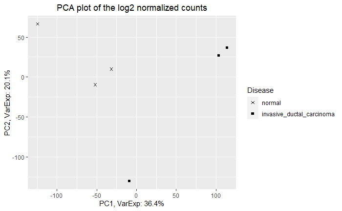

```r
PCA <- prcomp(t(normalized_counts), scale = FALSE)

percentVar <- round(100*PCA$sdev^2/sum(PCA$sdev^2),1)

dataGG <- data.frame("PC1" = PCA$x[,1],
                     "PC2" = PCA$x[,2],
                     "tmp" = rawData$sampleData[,Compare])

colnames(dataGG) = c("PC1","PC2",Compare)

p <- ggplot(dataGG, aes(PC1, PC2)) +
  geom_point(aes_string(shape = Compare)) +
  ggtitle("PCA plot of the log2 normalized counts") +
  xlab(paste0("PC1, VarExp: ", percentVar[1], "%")) +
  ylab(paste0("PC2, VarExp: ", percentVar[2], "%")) +
  theme(plot.title = element_text(hjust = 0.5))+
  scale_shape_manual(values = c(4,15))

print(p)

ggsave(file.path(saveFolder, "PCA_normalized.pdf"))
```

Next, we plot the heatmap that give a visual way to compare the distance between samples. We use the function *pheatmap* to plot the heatmap, and the variable *annotation_for_heatmap* is used for giving a name and property to the samples on the plot :

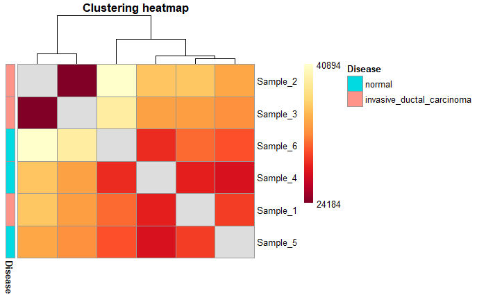

```r
annotation_for_heatmap <- data.frame("tmp" = rawData$sampleData[,Compare])
colnames(annotation_for_heatmap) = c(Compare)
row.names(annotation_for_heatmap) <- row.names(rawData$sampleData)

dists <- as.matrix(dist(t(normalized_counts), method = "manhattan"))

rownames(dists) <- row.names(rawData$sampleData)
hmcol <- rev(colorRampPalette(RColorBrewer::brewer.pal(9, "YlOrRd"))(255))
colnames(dists) <- NULL
diag(dists) <- NA

pheatmap(dists, col = (hmcol),
         annotation_row = annotation_for_heatmap,
         legend = TRUE,
         treeheight_row = 0,
         legend_breaks = c(min(dists, na.rm = TRUE),
                           max(dists, na.rm = TRUE)),
         legend_labels = (c(round(min(dists, na.rm = TRUE)),
                            round(max(dists, na.rm = TRUE)))),
         main = "Clustering heatmap")
```

```r
  dev.print(pdf, file.path(saveFolder, 'heatmap.pdf'))
```

### Step 10 : Generate and save the results of the differential analysis

First, we need to define the two property values that will be compared. We store then in the variable *CompareValues* :

```r
CompareValues<-c("normal", "invasive ductal carcinoma")
CompareValues <- gsub("\\s+", "_", CompareValues)
```

Then we perform the FoldChange using the function *results* from *DESEQ2*:

```r
deseq2Results <- results(deseq2Data, contrast=c(Compare, levels(factor(CompareValues))))
```

We create a *data.frame* from the results that will be saved in an xlsx file. We use the functions *add_column* to add the *SYMBOL* and *GENAME* IDs to the *data.frame* before saving it :

```r
deseq2ResDF <- as.data.frame(deseq2Results)
deseq2ResDF <- add_column(deseq2ResDF, SYMBOL = mapping$mapping_S[rownames(deseq2ResDF),], .after = 0)
deseq2ResDF <- add_column(deseq2ResDF, GENENAME = mapping$mapping_G[rownames(deseq2ResDF),], .after = 0)
deseq2ResDF <- add_column(deseq2ResDF, ID = rownames(deseq2ResDF), .after = 0)
write_xlsx(deseq2ResDF, file.path(saveFolder, "DiffExprRes.xlsx"))
deseq2ResDF$significant <- ifelse(deseq2ResDF$padj < 0.1, "Significant", NA)
```

Before plotting the results we add a final column that contains the value “Significant” if the adjusted p-values smaller than 0.1 and NA otherwise.

```r
deseq2ResDF$significant <- ifelse(deseq2ResDF$padj < 0.1, "Significant", NA)
```

### Step 11 : Plot the results of the differential analysis in 3 figures

First, we plot the mean of normalized counts against the foldChange value. As before, we use the function *ggplot* with the option *geom_point* to plots points in a 2D plan. Also, by using the option *colour=padj*, we color the points (that are associated to a RNA strand) using their adjusted p-value. In this case, we can see that the higher the fold change (in absolue value), the lower the adjusted p-value, which means that there is a statistically significant difference in the expression of the RNA strand between normal tissues and invasive ductal carcinoma tissues.

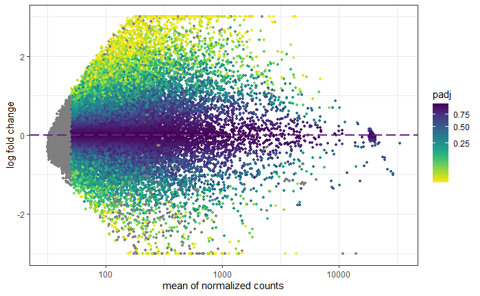

```r
  p<-ggplot(deseq2ResDF, aes(baseMean, log2FoldChange, colour=padj)) +
    geom_point(size=1) + scale_y_continuous(limits=c(-3, 3), oob=squish) +
    scale_x_log10() + geom_hline(yintercept = 0, colour="darkorchid4", size=1, linetype="longdash") +
    labs(x="mean of normalized counts", y="log fold change") +
    scale_colour_viridis(direction=-1, trans='sqrt') + theme_bw()
  print(p)
  ggsave(file.path(saveFolder, "fold_vs_count.pdf"))
```

The next plot is the same as the previous one, with the x and y axis inverted.

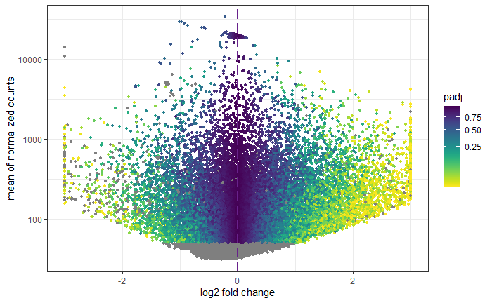

```r
  p<-ggplot(deseq2ResDF, aes(log2FoldChange, baseMean, colour=padj)) +
    geom_point(size=1) + scale_x_continuous(limits=c(-3, 3), oob=squish) +
    scale_y_log10() + geom_vline(xintercept = 0, colour="darkorchid4", size=1, linetype="longdash") +
    labs(y="mean of normalized counts", x="log2 fold change") +
    scale_colour_viridis(direction=-1, trans='sqrt') + theme_bw()

  print(p)
  ggsave(file.path(saveFolder, "count_vs_fold.pdf"))
```

Finally, we have the volcano plot that plots the fold change values against the adjusted p-values. We use the negative log2 of the adjusted p-values instead of just the adjusted p-values in order to facilitate the discrimination of points since the negative log function becomes exponentially high the closer we get to 0 and this is a property we want when comparing p-values.

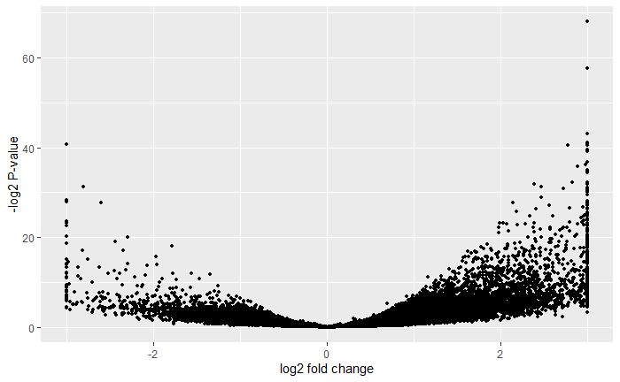

```r
  logdeseq2ResDF = deseq2ResDF
  logdeseq2ResDF$padj = -log2(logdeseq2ResDF$padj)

  p<-ggplot(logdeseq2ResDF, aes(log2FoldChange, padj)) +
    geom_point(size=1) + scale_x_continuous(limits=c(-3, 3), oob=squish) +
    labs(y="-log2 P-value", x="log2 fold change")

  print(p)

  ggsave(file.path(saveFolder, "volcano.pdf"))
```